# act_report

## WE RATE DOGS INSIGHTS AND VISUALIZATIONS

Tweets from the @dog_rates twitter account known as WeRateDogs were analyzed after being gathered from a variety of sources. These tweets are about dogs and include ratings for these dogs which are generally favorable because we love dogs. Tweet data analyzed include favorite count which are the likes a tweet get, retweet count which is the number of retweets and dog names to name a few.

From my analysis I came up with a few findings,

### Insight 1

There seems to be strong positive correlation (0.928) between likes and retweets which makes because a person is more likely to retweet a post if they like its content. In addition to this, after adding the ratings to my plot, i discovered that the tweet with higher number of likes and retweets and likes also tended to have higher as evidenced by the black bubbles on the top right quarter of our plot. This leads me to assume that higher rated dogs are also more 'liked' by the generally which means that the ratings probably conform with public opinion.

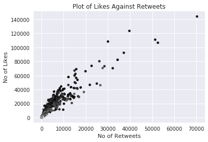

### Insight 2

The most popular dog names based on the tweets were Charlie, Cooper and Oliver which each had ten recorded entries.

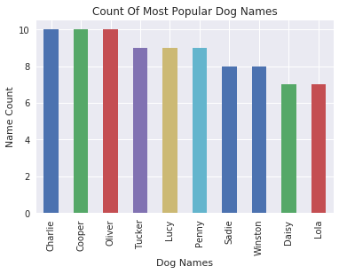

### Insight 3

Dog ratings tended to be more favorable than not. This is because dogs are sweethearts and we love them all. The few good dogs that got 'not so good' ratings were probably just having an off day.

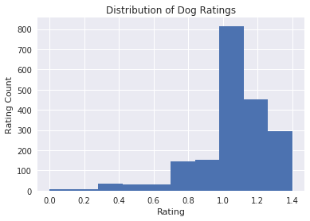

### Insight 4

Suprsingly, there was no obvious ryhme or reason to the order of the predictions. I had expected the top predictions which had the highest corresponding confidence levels to have the most accurate results but this proved to be untrue. The second prediction were slightly more accurate even though all three 3 predictions had almost the same degree of accuracy.

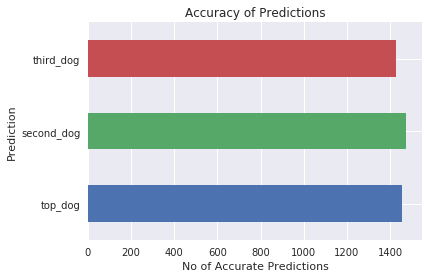